# DATA 101 Exam 1

Kamila Palys

Due: Monday 10/26 at 11:59pm

## Academic Honesty Statement (fill in your name)

I, Kamila Palys, hereby affirm that I have not communicated with or gained information in any way from my classmates or anyone other than the Professor during this exam, that I have not assisted anyone else with this exam, and that all work is my own.

## Load packages and data

```r
# load required packages here
library(tidyverse)
```

```r
# read in the data here
nba <- read_csv("data/nba_salaries.csv")
```

## Questions

### Question 1

First, we will make a table to view the salaries of the NBA players in descending order by using the “select” and “arrange” functions to display the variables we want, in the order we want.

```r
nba %>%
  select(player, salary) %>%
  arrange(desc(salary))
```

| player | salary |
| --- | --- |
| Kobe Bryant | 25.000000 |
| Joe Johnson | 24.894863 |
| LeBron James | 22.970500 |
| Carmelo Anthony | 22.875000 |
| Dwight Howard | 22.359364 |
| Chris Bosh | 22.192730 |
| Chris Paul | 21.468695 |
| Kevin Durant | 20.158622 |
| Derrick Rose | 20.093064 |
| Dwyane Wade | 20.000000 |

[output cut: 407 more lines]

From the table it is visible that Kobe Bryant has the highest salary of all the NBA players at $25 million, followed by Joe Johnson and then Lebron James.

### Question 2

Now we will create a boxplot that compares the distribution of the players’ salaries by position.

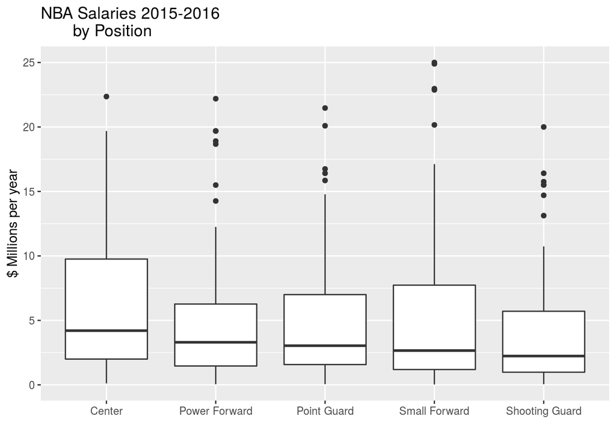

```r
ggplot(data = nba) +
  geom_boxplot(mapping = aes(x = position, y = salary)) +
  labs(title = "NBA Salaries 2015-2016
       by Position",
       x = "",
       y = "$ Millions per year") +
  scale_x_discrete(labels = c("Center", "Power Forward", "Point Guard",
                              "Small Forward", "Shooting Guard"))
```

To learn about the scale_x_discrete function, [I visited this website(https://ggplot2.tidyverse.org/reference/scale_discrete.html)]. From this graph, we are able to see that the highest median salary is earned by players with the center position, while the lowest median comes from the shooting guard players. The ones who play center, however, also have a more even spread of their salaries, seeing as their interquartile range, or the middle 50%, is the largest of all the positions. There are also very little outliers in the center players’ salaries, and there are several high outliers in all four of the other positions, so that is not to say that players playing a position other than center cannot earn a high salary.

### Question 3

Now we will take a look at how many players there are in each position with “group_by” and the “count” function.

```r
nba %>%
  group_by(position) %>%
  count(position) %>%
  arrange(desc(n))
```

| position | n |
| --- | --- |
| SG | 96 |
| PF | 85 |
| PG | 85 |
| SF | 82 |
| C | 69 |

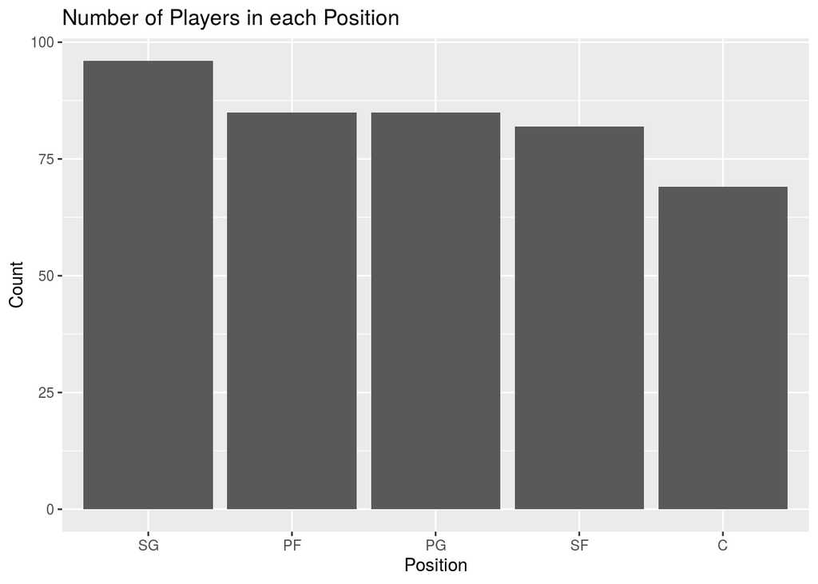

```r
ggplot(data = nba, mapping = aes(x = fct_infreq(position))) +
  geom_bar() +
  labs(title = "Number of Players in each Position",
       x = "Position",
       y = "Count")
```

With this table and bar graph, it is visible that there are the most players in shooting guard at 96, while the center position has only 69, which is the least amount of players playing a certain position. Additionally, there are 85 playing point guard, 85 playing power forward, and 82 playing small forward.

### Question 4

Here a display is created in the form of a histogram to show the distribution of the salaries of the NBA players.

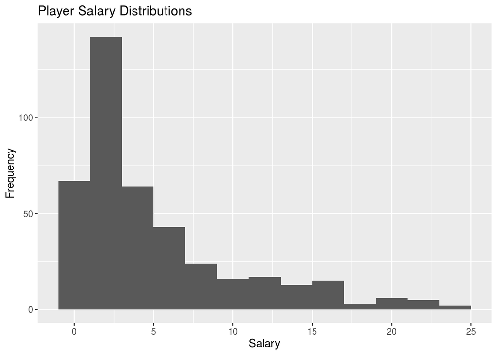

```r
ggplot(data = nba) +
  geom_histogram(mapping = aes(x = salary), binwidth = 2) +
  labs(title = "Player Salary Distributions",
       x = "Salary",
       y = "Frequency")
```

It is clear from this graph that a large number of players earned a salary between about $1 million to $3 million. It appears as though a large amount of players received a salary of up to $10 million, but a minority of them receive more than that and very few reach $20 million or more.

### Question 5

Here, the average salaries per player in each team will be displayed.

```r
nba %>%
  group_by(team) %>%
  summarise(avg_salary = mean(salary)) %>%
  arrange(desc(avg_salary)) %>%
  top_n(10)
```

| team | avg_salary |
| --- | --- |
| Cleveland Cavaliers | 10.231241 |
| Houston Rockets | 7.107153 |
| Miami Heat | 6.794056 |
| Golden State Warriors | 6.720367 |
| Chicago Bulls | 6.568408 |
| San Antonio Spurs | 6.511698 |
| Los Angeles Lakers | 6.237086 |
| Sacramento Kings | 6.216808 |
| Oklahoma City Thunder | 6.052010 |
| Dallas Mavericks | 5.978414 |

As seen, the three highest paying teams are the Cleveland Caveliers earning $10.23 million on average, Houston Rockets earning $7.11 million on average, and Miami heat with $6.79 million on average. The second and third highest earning teams do not have an extreme difference in average salaries per player, but the Cleveland Caveliers have a high jump, with each player earning almost $3 million more on average than the second highest earning team. It is possible that this may be due to the Cleveland Caveliers having more famous basketball players that earn a salary that is considered to be an outlier.

### Question 6

Here we will create a new variable called “salary_level” with three different levels regarding the salary a player makes: Low, Moderate, and High. Then, in a column called “proportion”, the proportion of players that fall within each salary level will be shown.

```r
nba %>%
  mutate(salary_level = case_when(
    salary < 8 ~ "Low",
    salary >= 8 & salary <16 ~ "Moderate",
    salary >= 16 ~ "High"
  )) %>%
  count(salary_level) %>%
  mutate(proportion = n/sum(n)) %>%
  arrange(match(salary_level, "Low", "Moderate", "High"))
```

| salary_level | n | proportion |
| --- | --- | --- |
| Low | 326 | 0.78177458 |
| High | 22 | 0.05275779 |
| Moderate | 69 | 0.16546763 |

As seen in the table above, there are 326 players that earn what we classify as a “low” salary, which is 0.782 of all players. Clearly, the majority of players (over 75%) earn what we call a “low” salary. There are 69 players that earn a “moderate” salary, making for 0.165 of all players, and only 22 players earn a “high” salary, which is 0.0528 of all players. To figure out how to rearrange the rows in my desired manner, [I visited this website: (https://stackoverflow.com/questions/26548495/reorder-rows-using-custom-order)]

### Question 7

The following table will show the highest salary earned for each position in each team.

```r
starters <- nba %>%
  group_by(team, position) %>%
  summarise(highest_salary = (max(salary))) %>%
  print()
```

```
## # A tibble: 147 x 3
## # Groups:   team [30]
##    team           position highest_salary
##    <chr>          <chr>             <dbl>
##  1 Atlanta Hawks  C                 12
##  2 Atlanta Hawks  PF                18.7
##  3 Atlanta Hawks  PG                 8
##  4 Atlanta Hawks  SF                 4
##  5 Atlanta Hawks  SG                 5.75
##  6 Boston Celtics C                  2.62
##  7 Boston Celtics PF                 5
##  8 Boston Celtics PG                 7.73
##  9 Boston Celtics SF                 6.80
## 10 Boston Celtics SG                 3.43
## # … with 137 more rows
```

I started this problem by creating a new dataframe with the new name and piping the nba dataset into the following functions. At first I started to use the select() function knowing that we would only display certain variables, but I later realized it was unnecessary. Since we are applying the maximum function in summarise to each position in each time, I grouped by the team and position. This gave me the new column that we needed, which I called highest_salary. I had to use the print() function so that the table would actually display.

### Question 8

Now, the names will be shown for each player that corresponds to the highest earning salary for each position in each team.

```r
starters <- left_join(starters, nba,
            by = c("highest_salary" = "salary", "position", "team")) %>%
            print()
```

```
## # A tibble: 148 x 4
## # Groups:   team [30]
##    team           position highest_salary player
##    <chr>          <chr>             <dbl> <chr>
##  1 Atlanta Hawks  C                 12    Al Horford
##  2 Atlanta Hawks  PF                18.7  Paul Millsap
##  3 Atlanta Hawks  PG                 8    Jeff Teague
##  4 Atlanta Hawks  SF                 4    Thabo Sefolosha
##  5 Atlanta Hawks  SG                 5.75 Kyle Korver
##  6 Boston Celtics C                  2.62 Tyler Zeller
##  7 Boston Celtics PF                 5    Jonas Jerebko
##  8 Boston Celtics PG                 7.73 Avery Bradley
##  9 Boston Celtics SF                 6.80 Jae Crowder
## 10 Boston Celtics SG                 3.43 Evan Turner
## # … with 138 more rows
```

I approached this problem by recognizing that I wanted to keep all the rows from the starters dataframe, and only add the players’ names that corresponded to the highest salary. Therefore, I used a left_join. I initially received many errors about the variable that I wanted to join by not existing, until I realized that I needed to note that the “highest_salary” in the starters dataframe contains the same information as the “salary” in the nba dataframe. In addition, to have the players’ names correspond to the correct team and position that they are a part of, I also had to join by the “position” and “team”.

### Question 9

If we wanted to see in which instances there are multiple highest paid players within a position in a team, we can first group by the team and the position, since it is within those combinations that we are looking for multiple values. Then, we can simply count how many values of highest_salary there are within a position in every team and display all 147 rows present in the table. We can quickly scan the “n” column and identify any observations where there is a 2, meaning that there are two players within a team earn the same highest salary in a given position. Alternatively, we can filter to only show results where there are more than one highest_salary per position per team, if we do not want to look through all 147 rows.

```r
starters %>%
  group_by(team, position) %>%
  count(highest_salary)
```

| team | position | highest_salary | n |
| --- | --- | --- | --- |
| Atlanta Hawks | C | 12.000000 | 1 |
| Atlanta Hawks | PF | 18.671659 | 1 |
| Atlanta Hawks | PG | 8.000000 | 1 |
| Atlanta Hawks | SF | 4.000000 | 1 |
| Atlanta Hawks | SG | 5.746479 | 1 |
| Boston Celtics | C | 2.616975 | 1 |
| Boston Celtics | PF | 5.000000 | 1 |
| Boston Celtics | PG | 7.730337 | 1 |
| Boston Celtics | SF | 6.796117 | 1 |
| Boston Celtics | SG | 3.425510 | 1 |

[output cut: 137 more lines]

```r
starters %>%
  group_by(team, position) %>%
  count(highest_salary) %>%
  filter(n > 1)
```

| team | position | highest_salary | n |
| --- | --- | --- | --- |
| Indiana Pacers | C | 4 | 2 |

In the first ten rows we see that there are only 1’s in the n column. If we were to scan all 147 rows, we would see that there is one case of the Indiana Pacers in the center position, where there are two players that both earn the highest salary of $4 million for that position. This can be confirmed by just looking at the raw data, where indeed both Ian Mahinmi and Jordan Hill earn $4 million playing the center position for the Indiana Pacers, which is the highest salary for that team and position. For our purposes, we will instead utilize the shorter and easier table to read, which only shows the one observation with the Indiana Pacers C position.

### Question 10

A new dataframe called starters_unique will now be created, which has Ian Mahinmi’s row removed so that there are no ties between the highest salaries within a position in a team. The resulting table will show the player with the highest salary for each position in each team in a format that is easy to read.

```r
starters_unique = starters[starters$player != "Ian Mahinmi", ]

starters_unique$highest_salary <- NULL

starters_unique %>%
  pivot_wider(names_from = position, values_from = player) %>%
  knitr::kable()
```

| team | C | PF | PG | SF | SG |
| --- | --- | --- | --- | --- | --- |
| Atlanta Hawks | Al Horford | Paul Millsap | Jeff Teague | Thabo Sefolosha | Kyle Korver |
| Boston Celtics | Tyler Zeller | Jonas Jerebko | Avery Bradley | Jae Crowder | Evan Turner |
| Brooklyn Nets | Andrea Bargnani | Thaddeus Young | Jarrett Jack | Joe Johnson | Bojan Bogdanovic |
| Charlotte Hornets | Al Jefferson | Marvin Williams | Kemba Walker | Michael Kidd-Gilchrist | Nicolas Batum |
| Chicago Bulls | Joakim Noah | Nikola Mirotic | Derrick Rose | Doug McDermott | Jimmy Butler |
| Cleveland Cavaliers | Tristan Thompson | Kevin Love | Kyrie Irving | LeBron James | Iman Shumpert |
| Dallas Mavericks | Zaza Pachulia | David Lee | Deron Williams | Chandler Parsons | Justin Anderson |
| Denver Nuggets | JJ Hickson | Kenneth Faried | Jameer Nelson | Danilo Gallinari | Gary Harris |
| Detroit Pistons | Aron Baynes | NA | Reggie Jackson | Stanley Johnson | Jodie Meeks |
| Golden State Warriors | Andrew Bogut | Draymond Green | Stephen Curry | Andre Iguodala | Klay Thompson |
| Houston Rockets | Dwight Howard | Terrence Jones | Ty Lawson | Trevor Ariza | James Harden |
| Indiana Pacers | Jordan Hill | Lavoy Allen | Rodney Stuckey | Paul George | Monta Ellis |
| Los Angeles Clippers | Cole Aldrich | Blake Griffin | Chris Paul | Paul Pierce | J.J. Redick |
| Los Angeles Lakers | Roy Hibbert | Julius Randle | D’Angelo Russell | Kobe Bryant | Louis Williams |
| Memphis Grizzlies | Marc Gasol | Zach Randolph | Mike Conley | Jeff Green | Tony Allen |
| Miami Heat | NA | Chris Bosh | Goran Dragic | Luol Deng | Dwyane Wade |
| Milwaukee Bucks | Miles Plumlee | Jabari Parker | Greivis Vasquez | Giannis Antetokounmpo | Khris Middleton |
| Minnesota Timberwolves | Nikola Pekovic | Kevin Garnett | Ricky Rubio | Shabazz Muhammad | Kevin Martin |
| New Orleans Pelicans | Omer Asik | Ryan Anderson | Jrue Holiday | Quincy Pondexter | Eric Gordon |
| New York Knicks | Robin Lopez | Kristaps Porzingis | Jose Calderon | Carmelo Anthony | Arron Afflalo |
| Oklahoma City Thunder | Enes Kanter | Serge Ibaka | Russell Westbrook | Kevin Durant | Dion Waiters |
| Orlando Magic | Nikola Vucevic | Channing Frye | Brandon Jennings | Tobias Harris | Victor Oladipo |
| Philadelphia 76ers | Joel Embiid | Carl Landry | Kendall Marshall | Gerald Wallace | Nik Stauskas |
| Phoenix Suns | Tyson Chandler | Mirza Teletovic | Eric Bledsoe | P.J. Tucker | Devin Booker |
| Portland Trail Blazers | Ed Davis | Meyers Leonard | Damian Lillard | Al-Farouq Aminu | Gerald Henderson |
| Sacramento Kings | DeMarcus Cousins | NA | Rajon Rondo | Rudy Gay | Marco Belinelli |
| San Antonio Spurs | Boris Diaw | LaMarcus Aldridge | Tony Parker | Kawhi Leonard | Danny Green |
| Toronto Raptors | Jonas Valanciunas | Patrick Patterson | Kyle Lowry | DeMarre Carroll | DeMar DeRozan |
| Utah Jazz | Tibor Pleiss | Trevor Booker | Dante Exum | Gordon Hayward | Alec Burks |
| Washington Wizards | Nene Hilario | Markieff Morris | John Wall | Martell Webster | Bradley Beal |

To remove Ian Mahinmi’s row from the starters dataframe, I used [code that I found on (https://statisticsglobe.com/r-remove-row-from-data-frame-condition)]. Then, I removed the column displaying the salary information using the [code that I found on (https://www.programmingr.com/examples/r-dataframe/add-delete-columns/)]. I then proceeded to pivot the starters_unique dataframe to be wider, knowing that the names of the new columns would be each of the positions, and the values underneath the corresponding columns would be the players’ names.